# Report for Godbout_StLawrence

## 1. The Data

Here is your dataset as we reprocessed it. Please take a look.

**Click to see the clean data**

```r
#
 study_data |>
          kable( format = "html") %>%
          kable_styling(position = "center", full_width = F, bootstrap_options = c("striped","hover"))%>%
          scroll_box( width = "1000px", height = "500px", fixed_thead = T)
```

| Entry | Study | Region | Site | Depth.m | Sample.Year | Sample.Month | Sample.Day | Latitude | Longitude | Taxon | Fixed.or.Random | Sample.Unit.Size.sq.m | Percent.Cover | Stipe.Density.num.per.sq.m | Individual.Density.num.per.sq.m | Biomass.kg.wet.per.sq.m |
| --- | --- | --- | --- | --- | --- | --- | --- | --- | --- | --- | --- | --- | --- | --- | --- | --- |
| 1 | Godbout_StLawrence | NA | Godbout | 6 | 2019 | 6 | 4 | 49.30155 | -67.67941 | Agarum clathratum | fixed | 5 | NA | NA | 0.0166667 | NA |
| 2 | Godbout_StLawrence | NA | Godbout | 6 | 2019 | 6 | 4 | 49.30155 | -67.67941 | Alaria esculenta | fixed | 5 | NA | NA | 0.0000000 | NA |
| 3 | Godbout_StLawrence | NA | Godbout | 6 | 2019 | 6 | 4 | 49.30155 | -67.67941 | Saccharina latissima | fixed | 5 | NA | NA | 0.0833333 | NA |
| 4 | Godbout_StLawrence | NA | Godbout | 2 | 2019 | 6 | 5 | 49.30239 | -67.67924 | Agarum clathratum | fixed | 5 | NA | NA | 0.0000000 | NA |
| 5 | Godbout_StLawrence | NA | Godbout | 2 | 2019 | 6 | 5 | 49.30239 | -67.67924 | Alaria esculenta | fixed | 5 | NA | NA | 7.5833333 | NA |
| 6 | Godbout_StLawrence | NA | Godbout | 2 | 2019 | 6 | 5 | 49.30239 | -67.67924 | Saccharina latissima | fixed | 5 | NA | NA | 2.9166667 | NA |
| 7 | Godbout_StLawrence | NA | Godbout | 2 | 2019 | 6 | 5 | 49.30265 | -67.69881 | Agarum clathratum | fixed | 5 | NA | NA | 0.0000000 | NA |
| 8 | Godbout_StLawrence | NA | Godbout | 2 | 2019 | 6 | 5 | 49.30265 | -67.69881 | Alaria esculenta | fixed | 5 | NA | NA | 4.1666667 | NA |
| 9 | Godbout_StLawrence | NA | Godbout | 2 | 2019 | 6 | 5 | 49.30265 | -67.69881 | Saccharina latissima | fixed | 5 | NA | NA | 0.1000000 | NA |
| 10 | Godbout_StLawrence | NA | Godbout | 6 | 2019 | 6 | 5 | 49.30217 | -67.69877 | Agarum clathratum | fixed | 5 | NA | NA | 3.1333333 | NA |
| 11 | Godbout_StLawrence | NA | Godbout | 6 | 2019 | 6 | 5 | 49.30217 | -67.69877 | Alaria esculenta | fixed | 5 | NA | NA | 0.0000000 | NA |
| 12 | Godbout_StLawrence | NA | Godbout | 6 | 2019 | 6 | 5 | 49.30217 | -67.69877 | Saccharina latissima | fixed | 5 | NA | NA | 0.0000000 | NA |
| 13 | Godbout_StLawrence | NA | Godbout | 6 | 2019 | 6 | 6 | 49.30217 | -67.69877 | Agarum clathratum | fixed | 5 | NA | NA | 3.1333333 | NA |
| 14 | Godbout_StLawrence | NA | Godbout | 6 | 2019 | 6 | 6 | 49.30217 | -67.69877 | Alaria esculenta | fixed | 5 | NA | NA | 0.0000000 | NA |
| 15 | Godbout_StLawrence | NA | Godbout | 6 | 2019 | 6 | 6 | 49.30217 | -67.69877 | Saccharina latissima | fixed | 5 | NA | NA | 0.0000000 | NA |
| 16 | Godbout_StLawrence | NA | Godbout | 2 | 2019 | 7 | 3 | 49.30239 | -67.67924 | Agarum clathratum | fixed | 5 | NA | NA | 0.0666667 | NA |
| 17 | Godbout_StLawrence | NA | Godbout | 2 | 2019 | 7 | 3 | 49.30239 | -67.67924 | Alaria esculenta | fixed | 5 | NA | NA | 5.9166667 | 5.2921600 |
| 18 | Godbout_StLawrence | NA | Godbout | 2 | 2019 | 7 | 3 | 49.30239 | -67.67924 | Saccharina latissima | fixed | 5 | NA | NA | 6.3333333 | 13.5006000 |
| 19 | Godbout_StLawrence | NA | Godbout | 2 | 2019 | 7 | 3 | 49.30265 | -67.69881 | Agarum clathratum | fixed | 5 | NA | NA | 1.0833333 | 0.2580000 |
| 20 | Godbout_StLawrence | NA | Godbout | 2 | 2019 | 7 | 3 | 49.30265 | -67.69881 | Alaria esculenta | fixed | 5 | NA | NA | 2.1833333 | 0.1960000 |
| 21 | Godbout_StLawrence | NA | Godbout | 2 | 2019 | 7 | 3 | 49.30265 | -67.69881 | Saccharina latissima | fixed | 5 | NA | NA | 0.0000000 | NA |
| 22 | Godbout_StLawrence | NA | Godbout | 6 | 2019 | 7 | 4 | 49.30155 | -67.67941 | Agarum clathratum | fixed | 5 | NA | NA | 0.9333333 | 0.2540000 |
| 23 | Godbout_StLawrence | NA | Godbout | 6 | 2019 | 7 | 4 | 49.30155 | -67.67941 | Alaria esculenta | fixed | 5 | NA | NA | 0.0000000 | NA |
| 24 | Godbout_StLawrence | NA | Godbout | 6 | 2019 | 7 | 4 | 49.30155 | -67.67941 | Saccharina latissima | fixed | 5 | NA | NA | 0.0166667 | 0.1484000 |
| 25 | Godbout_StLawrence | NA | Godbout | 6 | 2019 | 7 | 4 | 49.30217 | -67.69877 | Agarum clathratum | fixed | 5 | NA | NA | 3.2333333 | 0.8160000 |
| 26 | Godbout_StLawrence | NA | Godbout | 6 | 2019 | 7 | 4 | 49.30217 | -67.69877 | Alaria esculenta | fixed | 5 | NA | NA | 0.0000000 | NA |
| 27 | Godbout_StLawrence | NA | Godbout | 6 | 2019 | 7 | 4 | 49.30217 | -67.69877 | Saccharina latissima | fixed | 5 | NA | NA | 0.0000000 | NA |
| 28 | Godbout_StLawrence | NA | Godbout | 2 | 2019 | 8 | 6 | 49.30239 | -67.67924 | Agarum clathratum | fixed | 5 | NA | NA | 0.0333333 | NA |
| 29 | Godbout_StLawrence | NA | Godbout | 2 | 2019 | 8 | 6 | 49.30239 | -67.67924 | Alaria esculenta | fixed | 5 | NA | NA | 5.5833333 | NA |
| 30 | Godbout_StLawrence | NA | Godbout | 2 | 2019 | 8 | 6 | 49.30239 | -67.67924 | Saccharina latissima | fixed | 5 | NA | NA | 4.4500000 | NA |

[output cut: 166 more lines]

Here is your dataset as where we have now summed across all kelp species and put into the KelpTime main database format.

**Click to see the data in kelptime format**

```r
#|
kelptime_study |>
         kable( format = "html") %>%
         kable_styling(position = "center", full_width = F, bootstrap_options = c("striped","hover"))%>%
         scroll_box( width = "1000px", height = "500px", fixed_thead = T)
```

| study | site | period | latitude | longitude | sample_unit_size_sq_m | sasdate | max_depth | mean_depth | min_depth | biomass_kg_wet_per_sq_m | stipe_density_num_per_sq_m | individual_density_num_per_sq_m | percent_cover | has_bm | has_sd | has_id | has_pc | use_which | focalKelp | focalUnit | geometry | ecoregion | province | realm | focal_std_by_ecoregion | focal_std_by_province | focal_std_by_realm | ln_focal_std_by_ecoregion | ln_focal_std_by_province | … |
| --- | --- | --- | --- | --- | --- | --- | --- | --- | --- | --- | --- | --- | --- | --- | --- | --- | --- | --- | --- | --- | --- | --- | --- | --- | --- | --- | --- | --- | --- | --- |
| Godbout_StLawrence | Godbout | 1 | 49.30155 | -67.67941 | 5 | 2019-06-04 | 6 | 6.000000 | 6 | NA | 0.1000000 | 0.1000000 | NA | 12 | 34 | 34 | 0 | 2 | 0.1000000 | Stipe density | c(-67.67941, 49.30155) | Gulf of St. Lawrence - Eastern Scotian Shelf | Cold Temperate Northwest Atlantic | Temperate Northern Atlantic | 0.0010673 | 0.0004013 | 0.0004013 | -4.5037561 | -4.5658288 | … |
| Godbout_StLawrence | Godbout | 2 | 49.30240 | -67.69227 | 5 | 2019-06-05 | 6 | 3.333333 | 2 | NA | 5.9666667 | 5.9666667 | NA | 12 | 34 | 34 | 0 | 2 | 5.9666667 | Stipe density | c(-67.6922733333333, 49.3024033333333) | Gulf of St. Lawrence - Eastern Scotian Shelf | Cold Temperate Northwest Atlantic | Temperate Northern Atlantic | 0.0636851 | 0.0239415 | 0.0239415 | -2.6079543 | -3.3831155 | … |
| Godbout_StLawrence | Godbout | 3 | 49.30217 | -67.69877 | 5 | 2019-06-06 | 6 | 6.000000 | 6 | NA | 3.1333333 | 3.1333333 | NA | 12 | 34 | 34 | 0 | 2 | 3.1333333 | Stipe density | c(-67.69877, 49.30217) | Gulf of St. Lawrence - Eastern Scotian Shelf | Cold Temperate Northwest Atlantic | Temperate Northern Atlantic | 0.0334436 | 0.0125727 | 0.0125727 | -3.1362921 | -3.7910160 | … |
| Godbout_StLawrence | Godbout | 4 | 49.30219 | -67.68906 | 5 | 2019-06-15 | 6 | 4.000000 | 2 | NA | 20.7260684 | 20.7260684 | NA | 12 | 34 | 34 | 0 | 2 | 20.7260684 | Stipe density | c(-67.6890575, 49.30219) | Gulf of St. Lawrence - Eastern Scotian Shelf | Cold Temperate Northwest Atlantic | Temperate Northern Atlantic | 0.2212194 | 0.0831644 | 0.0831644 | -1.4643884 | -2.3733899 | … |
| Godbout_StLawrence | Godbout | 5 | 49.30252 | -67.68903 | 5 | 2019-07-03 | 2 | 2.000000 | 2 | 16.502680 | 7.7916667 | 7.7916667 | NA | 12 | 34 | 34 | 0 | 2 | 7.7916667 | Stipe density | c(-67.689025, 49.30252) | Gulf of St. Lawrence - Eastern Scotian Shelf | Cold Temperate Northwest Atlantic | Temperate Northern Atlantic | 0.0831642 | 0.0312644 | 0.0312644 | -2.3733914 | -3.1877540 | … |
| Godbout_StLawrence | Godbout | 6 | 49.30186 | -67.68909 | 5 | 2019-07-04 | 6 | 6.000000 | 6 | NA | 2.0916667 | 2.0916667 | NA | 12 | 34 | 34 | 0 | 2 | 2.0916667 | Stipe density | c(-67.68909, 49.30186) | Gulf of St. Lawrence - Eastern Scotian Shelf | Cold Temperate Northwest Atlantic | Temperate Northern Atlantic | 0.0223254 | 0.0083929 | 0.0083929 | -3.4319029 | -3.9957897 | … |
| Godbout_StLawrence | Godbout | 7 | 49.30219 | -67.68906 | 5 | 2019-07-15 | 6 | 4.000000 | 2 | NA | 66.1309524 | 66.1309524 | NA | 12 | 34 | 34 | 0 | 2 | 66.1309524 | Stipe density | c(-67.6890575, 49.30219) | Gulf of St. Lawrence - Eastern Scotian Shelf | Cold Temperate Northwest Atlantic | Temperate Northern Atlantic | 0.7058477 | 0.2653537 | 0.2653537 | -0.3342878 | -1.2896987 | … |
| Godbout_StLawrence | Godbout | 8 | 49.30252 | -67.68903 | 5 | 2019-08-06 | 2 | 2.000000 | 2 | NA | 9.4583333 | 9.4583333 | NA | 12 | 34 | 34 | 0 | 2 | 9.4583333 | Stipe density | c(-67.689025, 49.30252) | Gulf of St. Lawrence - Eastern Scotian Shelf | Cold Temperate Northwest Atlantic | Temperate Northern Atlantic | 0.1009534 | 0.0379520 | 0.0379520 | -2.1986452 | -3.0375541 | … |
| Godbout_StLawrence | Godbout | 9 | 49.30186 | -67.68909 | 5 | 2019-08-07 | 6 | 6.000000 | 6 | NA | 4.4666667 | 4.4666667 | NA | 12 | 34 | 34 | 0 | 2 | 4.4666667 | Stipe density | c(-67.68909, 49.30186) | Gulf of St. Lawrence - Eastern Scotian Shelf | Cold Temperate Northwest Atlantic | Temperate Northern Atlantic | 0.0476749 | 0.0179227 | 0.0179227 | -2.8529332 | -3.5783145 | … |
| Godbout_StLawrence | Godbout | 10 | 49.30219 | -67.68906 | 5 | 2019-08-15 | 6 | 4.000000 | 2 | NA | 21.9818182 | 21.9818182 | NA | 12 | 34 | 34 | 0 | 2 | 21.9818182 | Stipe density | c(-67.6890575, 49.30219) | Gulf of St. Lawrence - Eastern Scotian Shelf | Cold Temperate Northwest Atlantic | Temperate Northern Atlantic | 0.2346226 | 0.0882031 | 0.0882031 | -1.4080387 | -2.3207171 | … |
| Godbout_StLawrence | Godbout | 11 | 49.30219 | -67.68906 | 5 | 2019-10-15 | 6 | 4.000000 | 2 | NA | 59.8333333 | 59.8333333 | NA | 12 | 34 | 34 | 0 | 2 | 59.8333333 | Stipe density | c(-67.6890575, 49.30219) | Gulf of St. Lawrence - Eastern Scotian Shelf | Cold Temperate Northwest Atlantic | Temperate Northern Atlantic | 0.6386302 | 0.2400842 | 0.2400842 | -0.4328926 | -1.3859576 | … |
| Godbout_StLawrence | Godbout | 13 | 49.30265 | -67.69881 | 5 | 2019-12-09 | 2 | 2.000000 | 2 | NA | 9.7500000 | 9.7500000 | NA | 12 | 34 | 34 | 0 | 2 | 9.7500000 | Stipe density | c(-67.69881, 49.30265) | Gulf of St. Lawrence - Eastern Scotian Shelf | Cold Temperate Northwest Atlantic | Temperate Northern Atlantic | 0.1040665 | 0.0391224 | 0.0391224 | -2.1709739 | -3.0134410 | … |
| Godbout_StLawrence | Godbout | 14 | 49.30186 | -67.68909 | 5 | 2019-12-10 | 6 | 6.000000 | 6 | NA | 3.2833333 | 3.2833333 | NA | 12 | 34 | 34 | 0 | 2 | 3.2833333 | Stipe density | c(-67.68909, 49.30186) | Gulf of St. Lawrence - Eastern Scotian Shelf | Cold Temperate Northwest Atlantic | Temperate Northern Atlantic | 0.0350446 | 0.0131745 | 0.0131745 | -3.1001020 | -3.7647011 | … |
| Godbout_StLawrence | Godbout | 15 | 49.30212 | -67.69233 | 5 | 2019-12-15 | 6 | 4.666667 | 2 | NA | 50.3939394 | 50.3939394 | NA | 12 | 34 | 34 | 0 | 2 | 50.3939394 | Stipe density | c(-67.69233, 49.3021233333333) | Gulf of St. Lawrence - Eastern Scotian Shelf | Cold Temperate Northwest Atlantic | Temperate Northern Atlantic | 0.5378789 | 0.2022082 | 0.2022082 | -0.6017009 | -1.5501875 | … |
| Godbout_StLawrence | Godbout | 16 | 49.30252 | -67.68903 | 5 | 2020-02-05 | 2 | 2.000000 | 2 | NA | 9.2916667 | 9.2916667 | NA | 12 | 34 | 34 | 0 | 2 | 9.2916667 | Stipe density | c(-67.689025, 49.30252) | Gulf of St. Lawrence - Eastern Scotian Shelf | Cold Temperate Northwest Atlantic | Temperate Northern Atlantic | 0.0991745 | 0.0372833 | 0.0372833 | -2.2148081 | -3.0515987 | … |
| Godbout_StLawrence | Godbout | 17 | 49.30219 | -67.68906 | 5 | 2020-02-15 | 6 | 4.000000 | 2 | NA | 46.8818182 | 46.8818182 | NA | 12 | 34 | 34 | 0 | 2 | 46.8818182 | Stipe density | c(-67.6890575, 49.30219) | Gulf of St. Lawrence - Eastern Scotian Shelf | Cold Temperate Northwest Atlantic | Temperate Northern Atlantic | 0.5003924 | 0.1881156 | 0.1881156 | -0.6725755 | -1.6189045 | … |
| Godbout_StLawrence | Godbout | 18 | 49.30204 | -67.68581 | 5 | 2020-02-26 | 6 | 4.666667 | 2 | NA | 5.4833333 | 5.4833333 | NA | 12 | 34 | 34 | 0 | 2 | 5.4833333 | Stipe density | c(-67.6858066666667, 49.3020366666667) | Gulf of St. Lawrence - Eastern Scotian Shelf | Cold Temperate Northwest Atlantic | Temperate Northern Atlantic | 0.0585263 | 0.0220021 | 0.0220021 | -2.6805381 | -3.4419523 | … |
| Godbout_StLawrence | Godbout | 20 | 49.30219 | -67.68906 | 5 | 2020-07-09 | 6 | 4.000000 | 2 | 8.610039 | 9.0750000 | 9.0750000 | NA | 12 | 34 | 34 | 0 | 2 | 9.0750000 | Stipe density | c(-67.6890575, 49.30219) | Gulf of St. Lawrence - Eastern Scotian Shelf | Cold Temperate Northwest Atlantic | Temperate Northern Atlantic | 0.0968619 | 0.0364139 | 0.0364139 | -2.2362182 | -3.0701566 | … |
| Godbout_StLawrence | Godbout | 21 | 49.30219 | -67.68906 | 5 | 2020-07-15 | 6 | 4.000000 | 2 | NA | 44.8055556 | 44.8055556 | NA | 12 | 34 | 34 | 0 | 2 | 44.8055556 | Stipe density | c(-67.6890575, 49.30219) | Gulf of St. Lawrence - Eastern Scotian Shelf | Cold Temperate Northwest Atlantic | Temperate Northern Atlantic | 0.4782314 | 0.1797845 | 0.1797845 | -0.7169658 | -1.6618660 | … |
| Godbout_StLawrence | Godbout | 22 | 49.30252 | -67.68903 | 5 | 2020-10-05 | 2 | 2.000000 | 2 | 0.993440 | 8.4500000 | 8.4500000 | NA | 12 | 34 | 34 | 0 | 2 | 8.4500000 | Stipe density | c(-67.689025, 49.30252) | Gulf of St. Lawrence - Eastern Scotian Shelf | Cold Temperate Northwest Atlantic | Temperate Northern Atlantic | 0.0901909 | 0.0339060 | 0.0339060 | -2.3006775 | -3.1257033 | … |
| Godbout_StLawrence | Godbout | 24 | 49.30217 | -67.69877 | 5 | 2020-10-07 | 6 | 6.000000 | 6 | NA | 3.0166667 | 3.0166667 | NA | 12 | 34 | 34 | 0 | 2 | 3.0166667 | Stipe density | c(-67.69877, 49.30217) | Gulf of St. Lawrence - Eastern Scotian Shelf | Cold Temperate Northwest Atlantic | Temperate Northern Atlantic | 0.0321983 | 0.0121045 | 0.0121045 | -3.1653743 | -3.8119730 | … |
| Godbout_StLawrence | Godbout | 25 | 49.30165 | -67.68264 | 5 | 2020-10-08 | 6 | 6.000000 | 6 | NA | 1.1666667 | 1.1666667 | NA | 12 | 34 | 34 | 0 | 2 | 1.1666667 | Stipe density | c(-67.6826366666667, 49.3016533333333) | Gulf of St. Lawrence - Eastern Scotian Shelf | Cold Temperate Northwest Atlantic | Temperate Northern Atlantic | 0.0124524 | 0.0046813 | 0.0046813 | -3.7963578 | -4.2211802 | … |
| Godbout_StLawrence | Godbout | 26 | 49.30219 | -67.68906 | 5 | 2020-10-15 | 6 | 4.000000 | 2 | NA | 57.5575758 | 57.5575758 | NA | 12 | 34 | 34 | 0 | 2 | 57.5575758 | Stipe density | c(-67.6890575, 49.30219) | Gulf of St. Lawrence - Eastern Scotian Shelf | Cold Temperate Northwest Atlantic | Temperate Northern Atlantic | 0.6143399 | 0.2309526 | 0.2309526 | -0.4710604 | -1.4231549 | … |
| Godbout_StLawrence | Godbout | 27 | 49.30219 | -67.68906 | 5 | 2021-03-15 | 6 | 4.000000 | 2 | NA | 75.6666667 | 75.6666667 | NA | 12 | 34 | 34 | 0 | 2 | 75.6666667 | Stipe density | c(-67.6890575, 49.30219) | Gulf of St. Lawrence - Eastern Scotian Shelf | Cold Temperate Northwest Atlantic | Temperate Northern Atlantic | 0.8076270 | 0.3036163 | 0.3036163 | -0.2013490 | -1.1595852 | … |
| Godbout_StLawrence | Godbout | 28 | 49.30265 | -67.69881 | 5 | 2021-03-18 | 2 | 2.000000 | 2 | NA | 5.7166667 | 5.7166667 | NA | 12 | 34 | 34 | 0 | 2 | 5.7166667 | Stipe density | c(-67.69881, 49.30265) | Gulf of St. Lawrence - Eastern Scotian Shelf | Cold Temperate Northwest Atlantic | Temperate Northern Atlantic | 0.0610168 | 0.0229384 | 0.0229384 | -2.6448395 | -3.4131159 | … |
| Godbout_StLawrence | Godbout | 29 | 49.30228 | -67.68900 | 5 | 2021-03-19 | 6 | 4.000000 | 2 | NA | 2.1833333 | 2.1833333 | NA | 12 | 34 | 34 | 0 | 2 | 2.1833333 | Stipe density | c(-67.689005, 49.30228) | Gulf of St. Lawrence - Eastern Scotian Shelf | Cold Temperate Northwest Atlantic | Temperate Northern Atlantic | 0.0233038 | 0.0087607 | 0.0087607 | -3.4020845 | -3.9759893 | … |
| Godbout_StLawrence | Godbout | 30 | 49.30155 | -67.67941 | 5 | 2021-03-23 | 6 | 6.000000 | 6 | NA | 1.1000000 | 1.1000000 | NA | 12 | 34 | 34 | 0 | 2 | 1.1000000 | Stipe density | c(-67.67941, 49.30155) | Gulf of St. Lawrence - Eastern Scotian Shelf | Cold Temperate Northwest Atlantic | Temperate Northern Atlantic | 0.0117408 | 0.0044138 | 0.0044138 | -3.8285631 | -4.2395689 | … |
| Godbout_StLawrence | Godbout | 31 | 49.30265 | -67.69881 | 5 | 2021-06-15 | 2 | 2.000000 | 2 | NA | 139.2727273 | 139.2727273 | NA | 12 | 34 | 34 | 0 | 2 | 139.2727273 | Stipe density | c(-67.69881, 49.30265) | Gulf of St. Lawrence - Eastern Scotian Shelf | Cold Temperate Northwest Atlantic | Temperate Northern Atlantic | 1.4865253 | 0.5588387 | 0.5588387 | 0.4031460 | -0.5641583 | … |
| Godbout_StLawrence | Godbout | 35 | 49.30265 | -67.69881 | 5 | 2021-06-29 | 2 | 2.000000 | 2 | NA | 6.6500000 | 6.6500000 | NA | 12 | 34 | 34 | 0 | 2 | 6.6500000 | Stipe density | c(-67.69881, 49.30265) | Gulf of St. Lawrence - Eastern Scotian Shelf | Cold Temperate Northwest Atlantic | Temperate Northern Atlantic | 0.0709787 | 0.0266835 | 0.0266835 | -2.5135695 | -3.3054295 | … |
| Godbout_StLawrence | Godbout | 36 | 49.30204 | -67.68581 | 5 | 2021-06-30 | 6 | 4.666667 | 2 | NA | 2.7222222 | 2.7222222 | NA | 12 | 34 | 34 | 0 | 2 | 2.7222222 | Stipe density | c(-67.6858066666667, 49.3020366666667) | Gulf of St. Lawrence - Eastern Scotian Shelf | Cold Temperate Northwest Atlantic | Temperate Northern Atlantic | 0.0290556 | 0.0109231 | 0.0109231 | -3.2427691 | -3.8669038 | … |
| Godbout_StLawrence | Godbout | 38 | 49.30204 | -67.68581 | 5 | 2021-07-15 | 6 | 4.666667 | 2 | NA | 59.1444444 | 59.1444444 | NA | 12 | 34 | 34 | 0 | 2 | 59.1444444 | Stipe density | c(-67.6858066666667, 49.3020366666667) | Gulf of St. Lawrence - Eastern Scotian Shelf | Cold Temperate Northwest Atlantic | Temperate Northern Atlantic | 0.6312773 | 0.2373200 | 0.2373200 | -0.4442933 | -1.3970722 | … |
| Godbout_StLawrence | Godbout | 39 | 49.30252 | -67.68903 | 5 | 2021-10-14 | 2 | 2.000000 | 2 | NA | 0.2166667 | 0.2166667 | NA | 12 | 34 | 34 | 0 | 2 | 0.2166667 | Stipe density | c(-67.689025, 49.30252) | Gulf of St. Lawrence - Eastern Scotian Shelf | Cold Temperate Northwest Atlantic | Temperate Northern Atlantic | 0.0023126 | 0.0008694 | 0.0008694 | -4.3971331 | -4.5218051 | … |
| Godbout_StLawrence | Godbout | 41 | 49.30155 | -67.67941 | 5 | 2021-10-16 | 6 | 6.000000 | 6 | NA | 2.8500000 | 2.8500000 | NA | 12 | 34 | 34 | 0 | 2 | 2.8500000 | Stipe density | c(-67.67941, 49.30155) | Gulf of St. Lawrence - Eastern Scotian Shelf | Cold Temperate Northwest Atlantic | Temperate Northern Atlantic | 0.0304194 | 0.0114358 | 0.0114358 | -3.2084446 | -3.8426944 | … |
| Godbout_StLawrence | Godbout | 43 | 49.30217 | -67.69877 | 5 | 2021-10-18 | 6 | 6.000000 | 6 | NA | 5.1000000 | 5.1000000 | NA | 12 | 34 | 34 | 0 | 2 | 5.1000000 | Stipe density | c(-67.69877, 49.30217) | Gulf of St. Lawrence - Eastern Scotian Shelf | Cold Temperate Northwest Atlantic | Temperate Northern Atlantic | 0.0544348 | 0.0204640 | 0.0204640 | -2.7421019 | -3.4912095 | … |

## 2. Plots of raw data

### 2.1 By metric

Here is what your data looks like with all sites plotted together looking at each sampling metric.

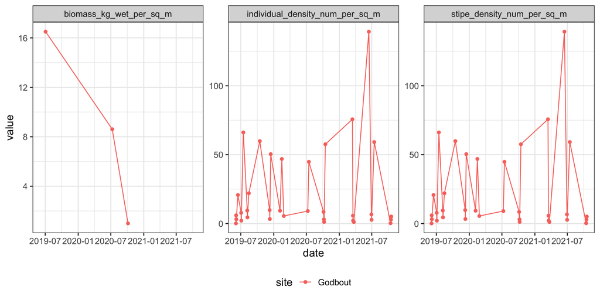

```r
kelptime_study_measurement_long <-
  kelptime_study |>
  tidyr::pivot_longer(cols =biomass_kg_wet_per_sq_m:percent_cover) |>
  filter(!is.na(value))

ggplot(kelptime_study_measurement_long,
       aes(x = date, y = value,
           color = site)) +
  geom_point() +
  geom_line() +
  facet_wrap(vars(name), scale = "free_y")
```

### 2.2 Standardized data

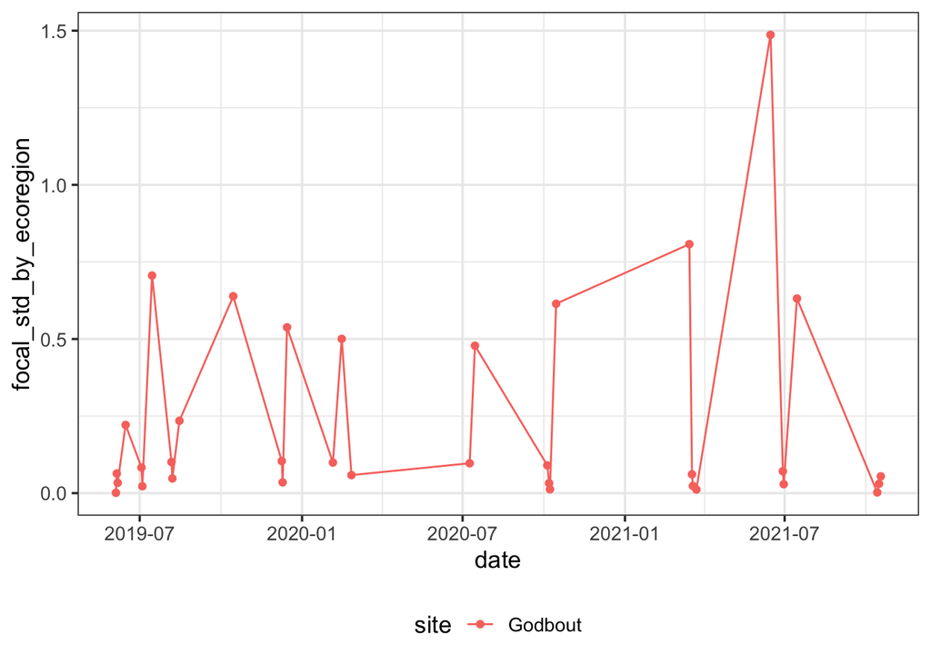

```r
ggplot(kelptime_study,
       aes(x = date, y = focal_std_by_ecoregion,
           color = site)) +
  geom_point() +
  geom_line()
```

### 2.3 Standardized data by site

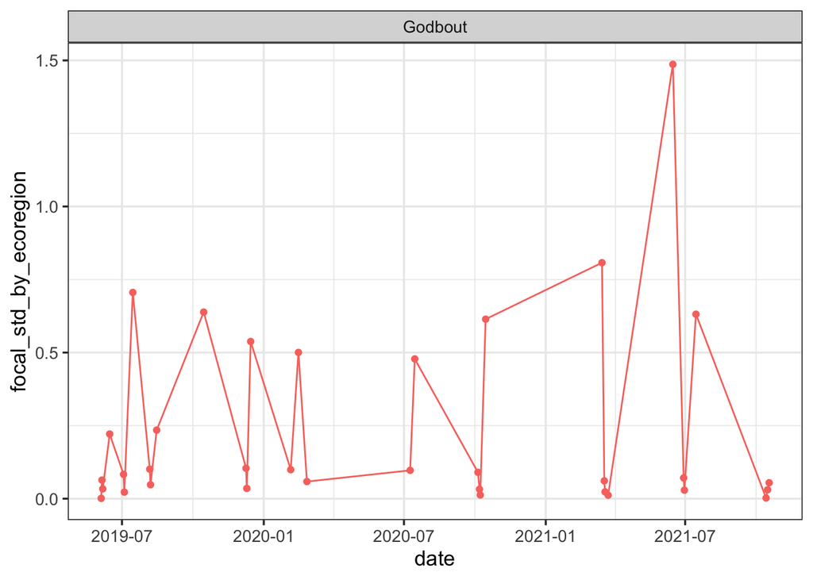

```r
ggplot(kelptime_study,
       aes(x = date, y = focal_std_by_ecoregion,
           color = site)) +
  geom_point() +
  geom_line() +
  facet_wrap(vars(site)) +
  guides(color = "none")
```

## 3. Modeled timeseries resuls

We fit two models. One where the slope varies by ecoregion (note: the GOSL and Newfoundland are collapsed) and one where the slope does not vary by ecoregion. Based on the modeled results, here is the smoothed fits to your data. Note - thus far, the model with a common slope appears to be the correct is the one with a common slope (best fit in terms of prediction and p-value for slope*ecoregion is not distinguishable from 0).

**Note** - the study (black) line might not line up in the middle or on trajectories, as it is shrunken in towards the grand mean for the ecoregion.

### 3.1 Slope Varying by Ecoregion Model

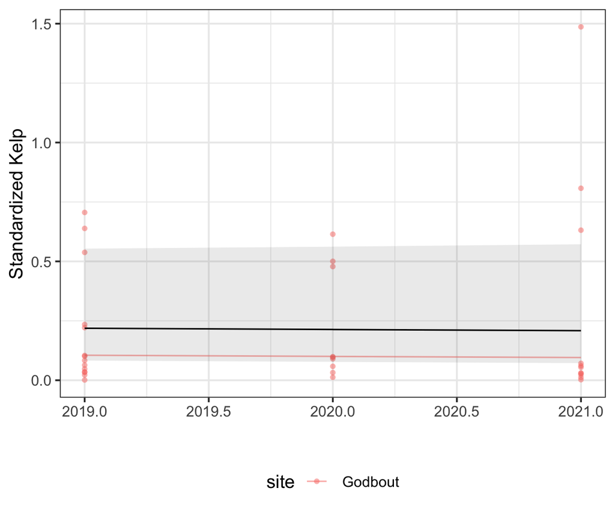

```r
mod_ecoregion <- readRDS("models/mod_ecoregion.rds")


# for plotting to do the back transform
exp_trans <- function(dat){

  dat |>
    mutate(
      Predicted = exp(Predicted)-0.01,
           CI_low = exp(CI_low)-0.01,
           CI_high = exp(CI_high)-0.01,
           CI_high = ifelse(CI_high>1.1, 1.1, CI_high)
    )|>
               mutate(trajectory =
                        gsub(study[1], "", trajectory))

}


re_ecoregion <- ranef(mod_ecoregion)$cond$study |>
  as_tibble(rownames = "study")  |>
  filter(study == params$study) |>
  pull(`(Intercept)`)


dat_fixed_ecoregion <- estimate_relation(mod_ecoregion,
                               include_random = FALSE,
                  length = 200,
                  data = kelptime_study) |>
  mutate(Predicted = Predicted + re_ecoregion,
         CI_high = CI_high + re_ecoregion,
         CI_low = CI_low + re_ecoregion) |>
  exp_trans()

dat_traj_ecoregion <- estimate_relation(mod_ecoregion,
                              include_random = TRUE,
                  length = 200,
                  data = kelptime_study) |>
    exp_trans()


ggplot(dat_traj_ecoregion, aes(x = year)) +
  geom_line(aes(y = Predicted,
                color = trajectory), alpha = 0.5) +
  geom_point(aes(y = focal_std_by_ecoregion,
                 group = trajectory,
                 shape = trajectory,
                 color = trajectory), alpha = 0.5,
             data = kelptime_study |>
               mutate(trajectory =
                        gsub(study[1], "", trajectory))) +
  geom_line(data = dat_fixed_ecoregion,
            aes(y = Predicted), color = "black") +
  geom_ribbon(data = dat_fixed_ecoregion,
            aes(y = Predicted,
                ymin = CI_low,
                ymax = CI_high), color = NA,
            alpha = 0.1) +
  labs(x = "", y = "Standardized Kelp",
      color = "site", shape = "site")
```

### 3.2 Common Slope Model

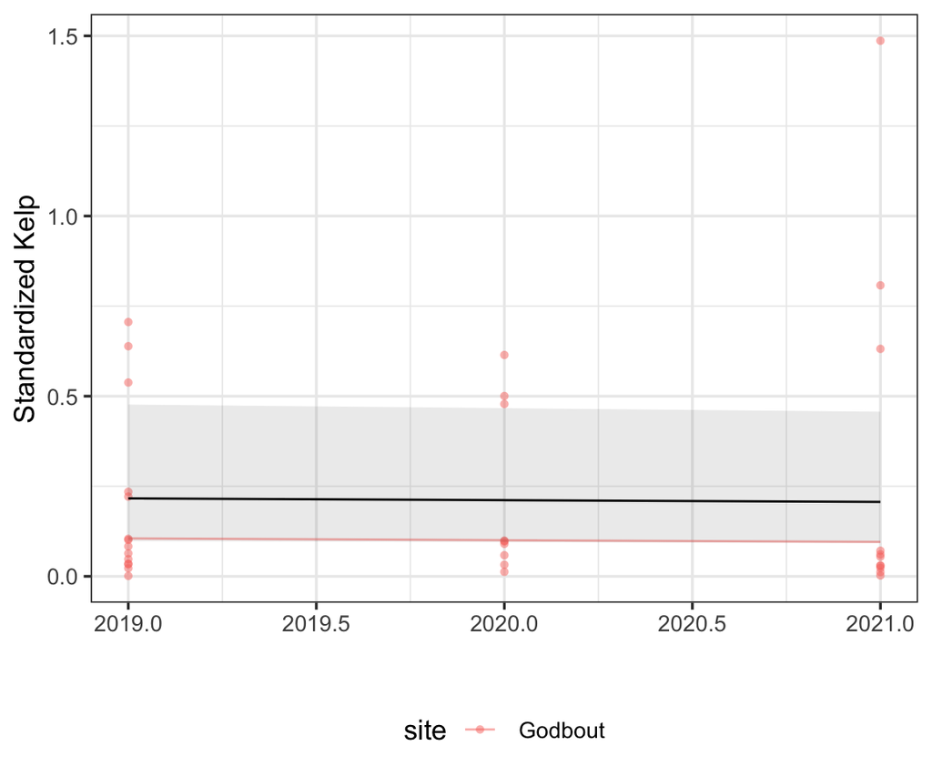

```r
mod_common_slope <- readRDS("models/mod_common_slope.rds")

re <- ranef(mod_common_slope)$cond$study |>
  as_tibble(rownames = "study")  |>
  filter(study == params$study) |>
  pull(`(Intercept)`)


dat_fixed <- estimate_relation(mod_common_slope,
                               include_random = FALSE,
                  length = 200,
                  data = kelptime_study) |>
  mutate(Predicted = Predicted + re,
         CI_high = CI_high + re_ecoregion,
         CI_low = CI_low + re_ecoregion) |>
  exp_trans()

dat_traj <- estimate_relation(mod_common_slope,
                              include_random = TRUE,
                  length = 200,
                  data = kelptime_study) |>
    exp_trans()

ggplot(dat_traj, aes(x = year)) +
  geom_line(aes(y = Predicted,
                color = trajectory), alpha = 0.5) +
  geom_point(aes(y = focal_std_by_ecoregion,
                 group = trajectory,
                 shape = trajectory,
                 color = trajectory), alpha = 0.5,
             data = kelptime_study |>
               mutate(trajectory =
                        gsub(study[1], "", trajectory))) +
  geom_line(data = dat_fixed,
            aes(y = Predicted), color = "black") +
  geom_ribbon(data = dat_fixed,
            aes(y = Predicted,
                ymin = CI_low,
                ymax = CI_high), color = NA,
            alpha = 0.1) +
  labs(x = "", y = "Standardized Kelp",
      color = "site", shape = "site")
```